# Online Dating Usage has Grown Rapidly in Recent Years, A Possible Missing Market to Target

Kelly Mejia Breton

April 24, 2016

In many cultures matchmaking and arrange marriages are common. Today technology developments have advanced matchmaking to connect people with good matches.

**According to Pew Research Center:**

• The general public perception towards online dating has become much more positive since 2005 • One in ten Americans have used an online dating service themselves • Many people know someone using online dating, or who has found a spouse / long-term long-term partner via online dating

**Dataset:**

• Provided by Pew Research Center • Survey completed in 2013 via telephone • 2,252 adults participated, 185 variables

With the internet, along with mobile making it easier for us to access the internet, and trendy social networking sites, I wonder if online dating services are capturing all potential markets?

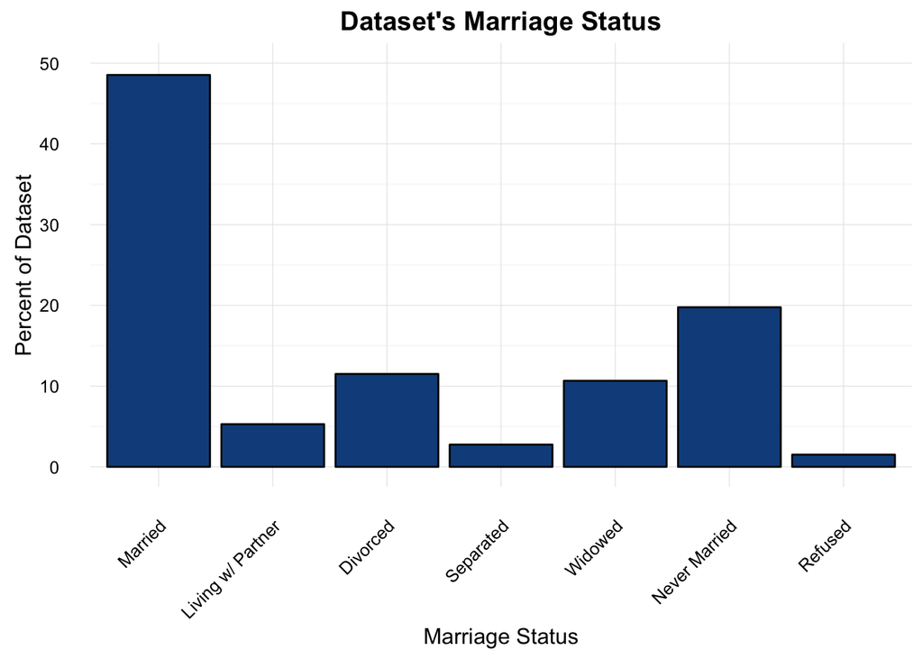

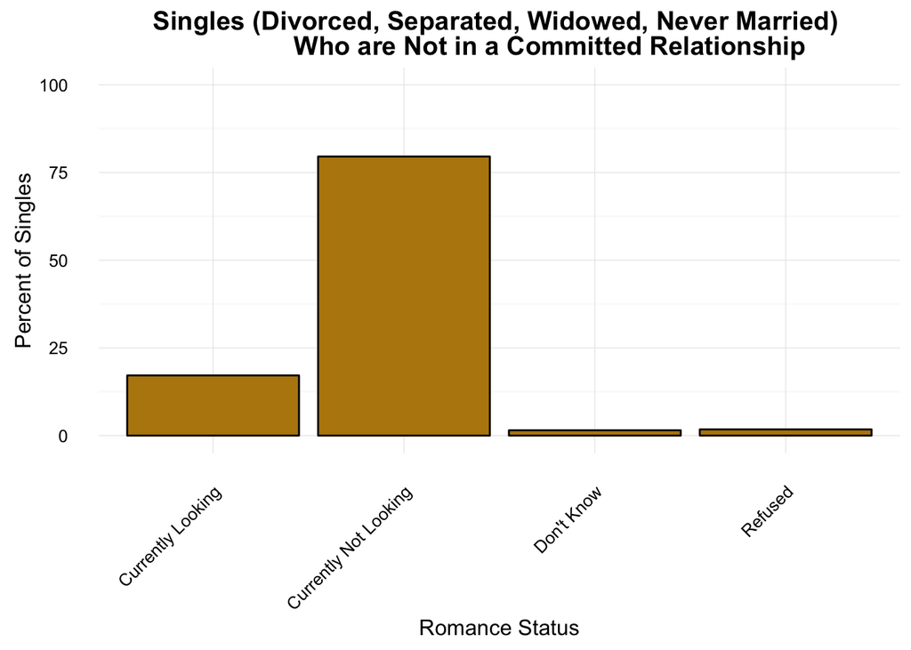

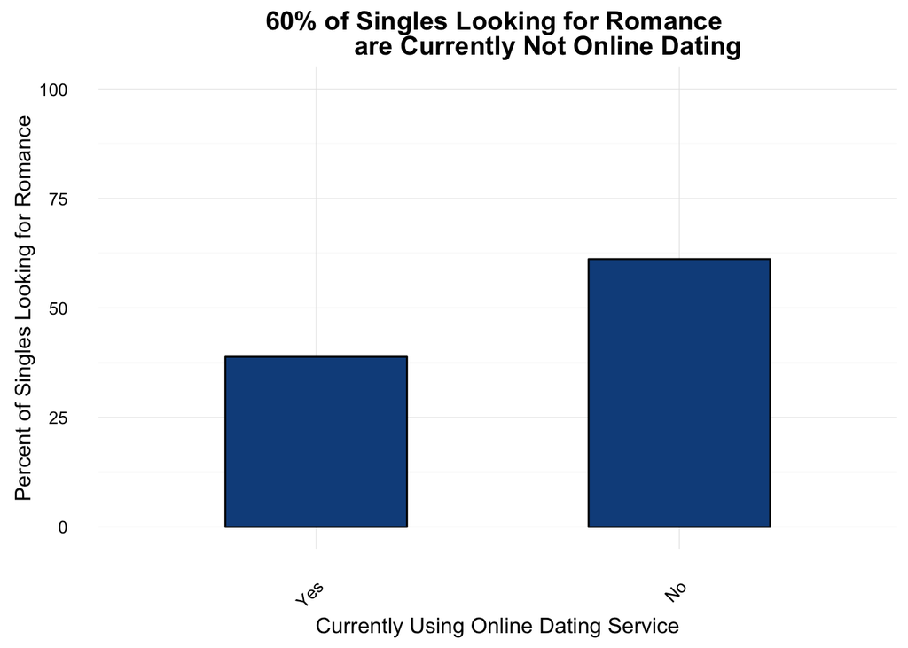

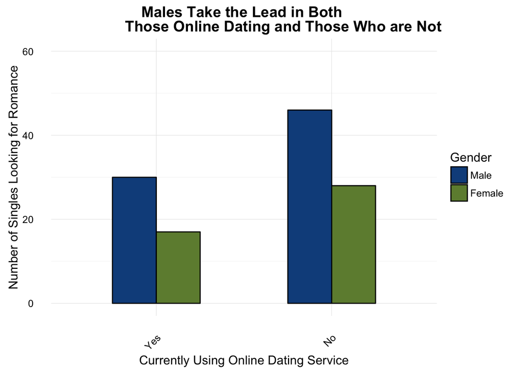

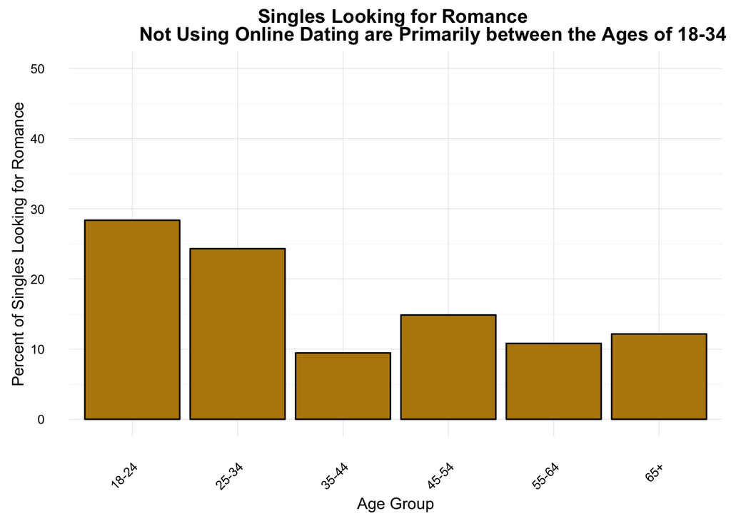

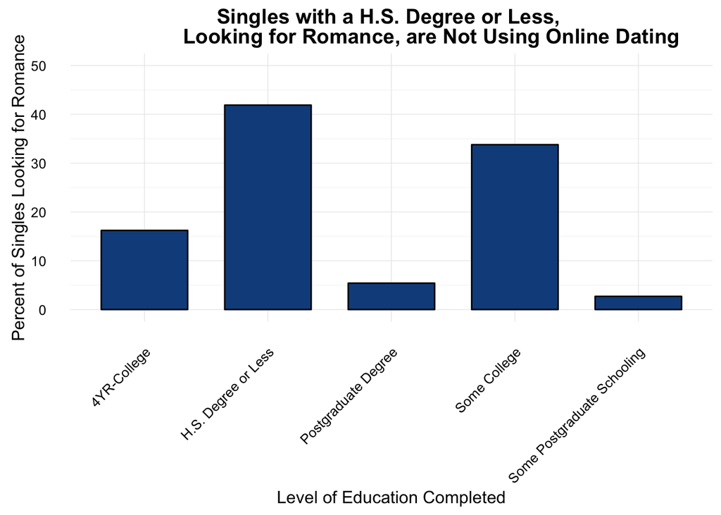

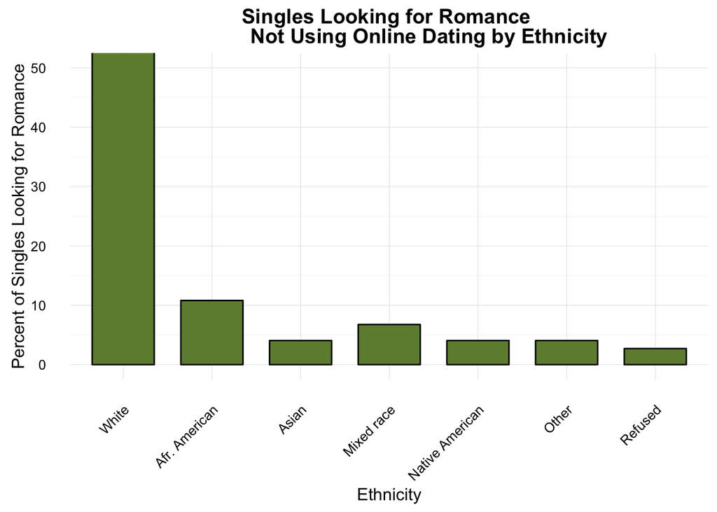

```r
library(ggplot2)
library(dplyr)
library(ggthemes)
setwd("/Users/AlexandKelly/rkelly")
online=read.csv("online.csv", stringsAsFactors = FALSE)

#subseting the original dataset with the main variables used in the presentation
sub_online=select(online, sex, intuse, q1, mar, mar2, mar4, date1a, date2a, date6, age, race, date9a, date9b, date9c, date9d, educ2)


#Creating new columns labeling the factor variables
sub_online_status=mutate(sub_online,
                         mar_status=factor(
                                 sub_online$mar, c(1,2,3,4,5,6,8,9),
                                 c("Married", "Living w/ Partner",
                                   "Divorced", "Separated", "Widowed", "Never Married",
                                   "Don't Know", "Refused")),
                         mar2_status=factor(
                                 sub_online$mar2, c(1,2,8,9),
                                 c("In Committed Relationship", "Not In Committed Relationship",
                                   "Don't Know", "Refused")),
                         mar4_status=factor(
                                 sub_online$mar4, c(1,2,8,9),
                                 c("Currently Looking", "Currently Not Looking",
                                   "Don't Know", "Refused")),
                         sex_status=factor(
                                 sub_online$sex, c(1,2),
                                 c("Male", "Female")),
                         date1a_status=factor(
                                 sub_online$date1a, c(1,2,8,9),
                                 c("Yes", "No",
                                   "Don't Know", "Refused")),
                         date6_status=factor(
                                 sub_online$date6, c(1,2,8,9),
                                 c("Yes", "No",
                                   "Don't Know", "Refused")),
                         race_status=factor(
                                 sub_online$race, c(1,2,3,4,5,6,8,9),
                                 c("White", "Afr. American", "Asian", "Mixed race",
                                   "Native American", "Other", "Don't Know", "Refused")),
                         date9a_status=factor(
                                 sub_online$date9a, c(1,2,8,9),
                                 c("Agree", "Disagree",
                                   "Don't Know", "Refused")),
                         date9b_status=factor(
                                 sub_online$date9b, c(1,2,8,9),
                                 c("Agree", "Disagree",
                                   "Don't Know", "Refused")),
                         date9c_status=factor(
                                 sub_online$date9c, c(1,2,8,9),
                                 c("Agree", "Disagree",
                                   "Don't Know", "Refused")),
                         date9d_status=factor(
                                 sub_online$date9d, c(1,2,8,9),
                                 c("Agree", "Disagree",
                                   "Don't Know", "Refused")),
                         age_status=ifelse(age<25,"18-24",
                                           ifelse(age<35 & age>24, "25-34",
                                                  ifelse(age<45 & age>34, "35-44",
                                                         ifelse(age<55 & age>44, "45-54",
                                                                ifelse(age<65 & age>54,"55-64","65+"))))),
                         educ2_status=ifelse(educ2<=3,"H.S. Degree or Less",
                                             ifelse(educ2==4, "Some College",
                                                    ifelse(educ2==5, "Some College",
                                                           ifelse(educ2==6, "4YR-College",
                                                                  ifelse(educ2==7, "Some Postgraduate Schooling",
                                                                         ifelse(educ2==8,"Postgraduate Degree",
                                                                                ifelse(educ2==98,"Don't Know", "Refused")))))))
)
```

# **Conclusions**

• 60% of singles looking for romance are currently not using Online Dating sites.  
• From this group it seems the target are adults who fall in the following groups: o Gender: Males o Age: Between the ages of 18-34 o Education: Holding a H.S. Degree or less o Ethnicity: White American

# **Next Steps**

• Analyze the main location of the target; is it a possible regional market? • Search for data released in the last year, compare the findings • Look for possible relationships between other variables